# Data Visualization

Joseph Walker

9/12/2017

**Exploratory Visaulizations** help us explain the data.

- Helps you see what is in your data
- Level of detail:
  - Keep as much detail as possible
  - Practical limit: how much can you see and interpret?

**Explanatory Visualizations** help us share our data with others.

- Shows others what you’ve found in your data
- Requires editorial decisions:
  - Highlight the key features you want to emphasize
  - Eliminate extraneous details

par(mfrow = c(rows, columns)) plot, (data, type = o,l,p,s)

```r
names(par())
```

```
##  [1] "xlog"      "ylog"      "adj"       "ann"       "ask"
##  [6] "bg"        "bty"       "cex"       "cex.axis"  "cex.lab"
## [11] "cex.main"  "cex.sub"   "cin"       "col"       "col.axis"
## [16] "col.lab"   "col.main"  "col.sub"   "cra"       "crt"
## [21] "csi"       "cxy"       "din"       "err"       "family"
## [26] "fg"        "fig"       "fin"       "font"      "font.axis"
## [31] "font.lab"  "font.main" "font.sub"  "lab"       "las"
## [36] "lend"      "lheight"   "ljoin"     "lmitre"    "lty"
## [41] "lwd"       "mai"       "mar"       "mex"       "mfcol"
## [46] "mfg"       "mfrow"     "mgp"       "mkh"       "new"
## [51] "oma"       "omd"       "omi"       "page"      "pch"
## [56] "pin"       "plt"       "ps"        "pty"       "smo"
## [61] "srt"       "tck"       "tcl"       "usr"       "xaxp"
## [66] "xaxs"      "xaxt"      "xpd"       "yaxp"      "yaxs"
## [71] "yaxt"      "ylbias"
```

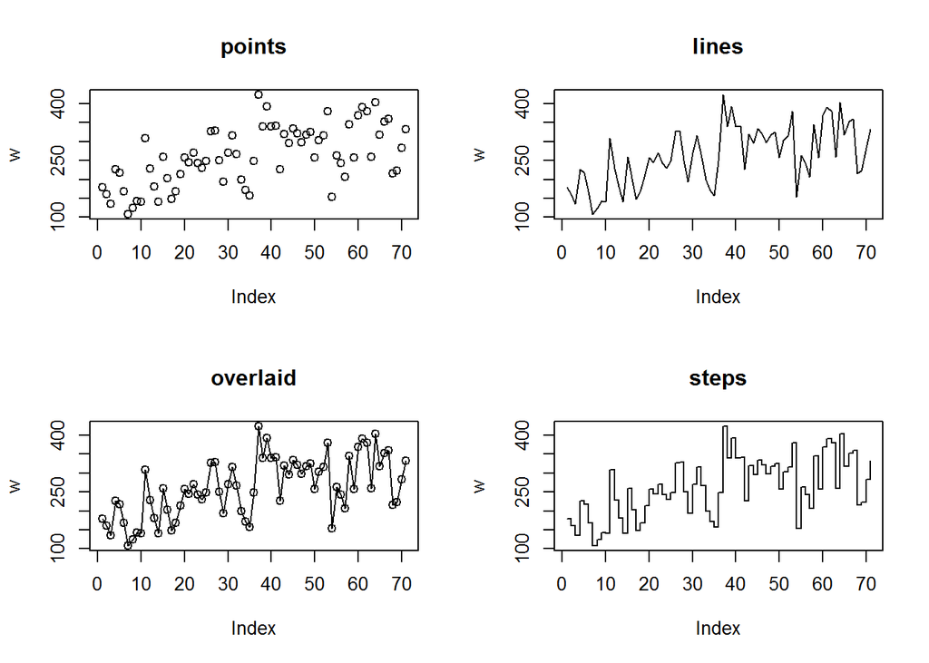

```r
# Set up a 2-by-2 plot array
par(mfrow = c(2,2))

w <- chickwts$weight
# Plot the chick weights  data as points
plot(w, type = "p")

# Add the title
title("points")

# Plot the chick weights with lines
plot(w, type = "l")

# Add the title
title("lines")

# Plot the chick weights as lines overlaid with points
plot(w, type  = "o")

# Add the title
title("overlaid")

# Plot the chick weights as steps
plot(w, type = "s")

# Add the title
title("steps")
```

```r
#load MASS package for the Cars93 dataset
library(MASS)
```

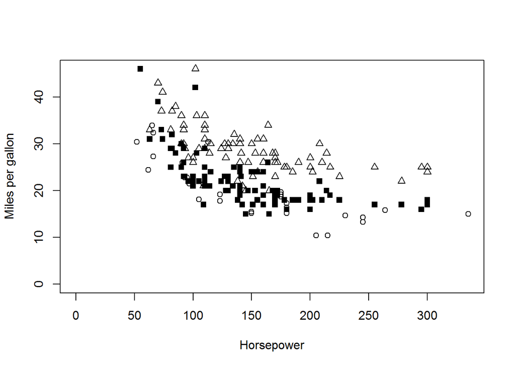

```r
#assign datasets to variables
c1 <- Cars93
c2 <- mtcars

#compute max_hp
max_hp <- max(c1$Horsepower, c2$hp)

#compute max_mpg
max_mpg <- max(c1$MPG.city, c2$mpg)

# Create empty plot with type = "n"
plot(max_hp, max_mpg,
     type = "n", xlim = c(0, max_hp),
     ylim = c(0, max_mpg), xlab = "Horsepower",
     ylab = "Miles per gallon")

# Add open circles to plot
points(y =c2$mpg, x =c2$hp, pch = 1)

# Add solid squares to plot
points(y = c1$MPG.city, x = c1$Horsepower, pch = 15)

# Add open triangles to plot
points(y = c1$MPG.highway, x = c1$Horsepower, pch = 2)
```

# Managing Visual Complexity

Too many details can detract from a plot. In addition, more plots is not necessarily more useful.

The `matplot` function allows you to plot multiple columns on an axis but as we will see, too much data can disrupt your plot.

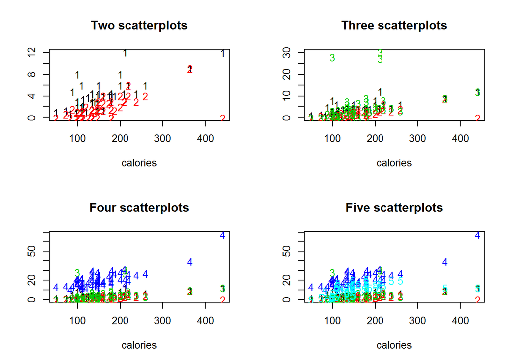

```r
# Construct the vector keep_vars
keep_vars <- c("calories", "protein", "fat",
               "fibre", "carbo", "sugars")

# Use keep_vars to extract the desired subset of UScereal
df <- UScereal[, keep_vars]

# Set up a two-by-two plot array
par(mfrow = c(2,2))

# Use matplot() to generate an array of two scatterplots
matplot(y = UScereal[, c("protein", "fat")], x  = UScereal$calories, xlab = "calories", ylab = "")

# Add a title
title("Two scatterplots")

# Use matplot() to generate an array of three scatterplots
matplot(y = UScereal[, c("protein", "fat", "fibre")], x = UScereal$calories, xlab = "calories", ylab = "")

# Add a title
title(main = "Three scatterplots")

# Use matplot() to generate an array of four scatterplots
matplot(y = UScereal[, c("protein", "fat", "fibre", "carbo")], x = UScereal$calories, xlab = "calories", ylab = "")

# Add a title
title(main = "Four scatterplots")

# Use matplot() to generate an array of five scatterplots
matplot(y = UScereal[, c("protein", "fat", "fibre", "carbo", "sugars")], x = UScereal$calories, xlab = "calories", ylab = "")

# Add a title
title(main = "Five scatterplots")
```

# Multiple plot arrays

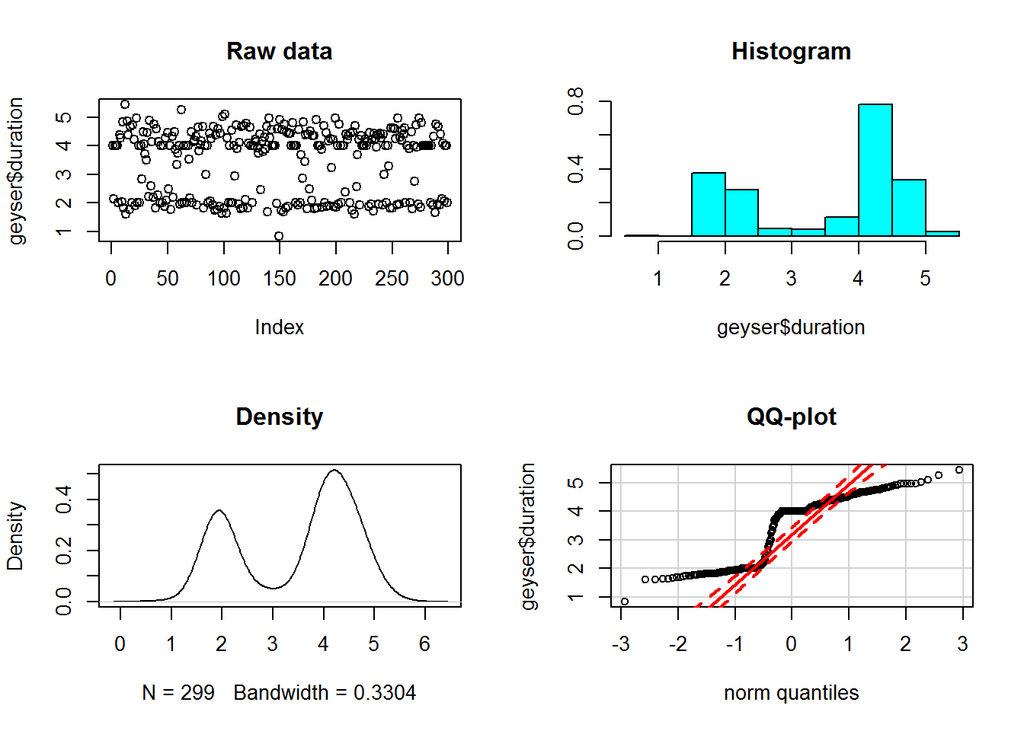

```r
# Set up a two-by-two plot array
par(mfrow = c(2,2))

# Plot the raw duration data
plot(geyser$duration, main = "Raw data")

# Plot the normalized histogram of the duration data
truehist(geyser$duration, main = "Histogram")

# Plot the density of the duration data
plot(density(geyser$duration), main = "Density")

# Construct the normal QQ-plot of the duration data (qqPlot comes from the 'car' package)
car::qqPlot(x = geyser$duration, main = "QQ-plot")
```

Constructing & Displaing Layout Matrices

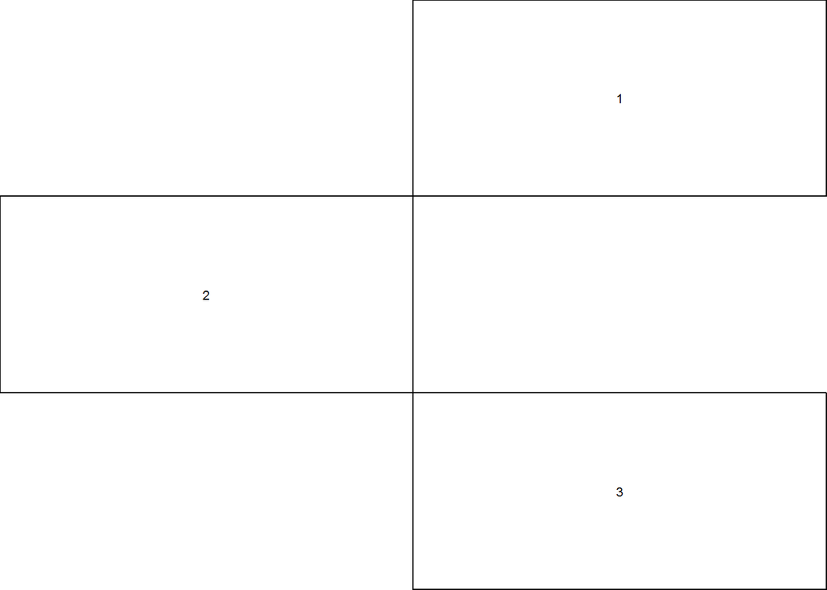

```r
# Use the matrix function to create a matrix with three rows and two columns
layoutMatrix <- matrix(
  c(0, 1,
    2, 0,
    0, 3),
  byrow = TRUE,
  nrow = 3
)

# Call the layout() function to set up the plot array
layout(layoutMatrix)

# Show where the three plots will go
layout.show(3)
```

Now we will use a similar layout matrix and apply it to some plots using data from the `whiteside` dataset from the `MASS` package.

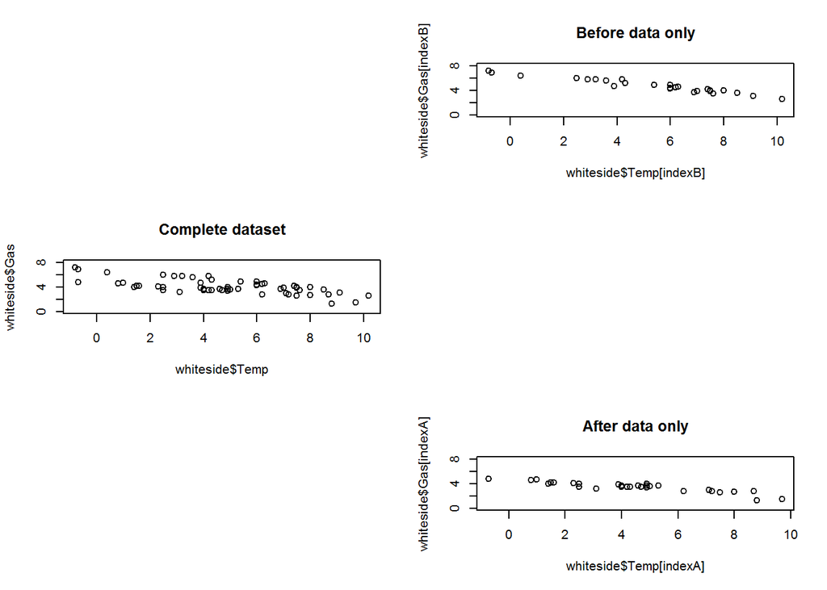

```r
# Set up the plot array
layout(layoutMatrix)

# Construct vectors indexB and indexA
indexB <- which(whiteside$Insul == "Before")
indexA <- which(whiteside$Insul == "After")

# Create plot 1 and add title
plot(whiteside$Temp[indexB], whiteside$Gas[indexB],
     ylim = c(0,8),
title("Before data only"))

# Create plot 2 and add title
plot(whiteside$Temp, whiteside$Gas,
     ylim = c(0,8),
title("Complete dataset"))

# Create plot 3 and add title
plot(whiteside$Temp[indexA], whiteside$Gas[indexA],
     ylim = c(0,8),
title("After data only"))
```

And finally, we can create arrays for different sized plots using the `layout matrix`.

The `Boston` dataset from the `MASS` package us used in the following examples.

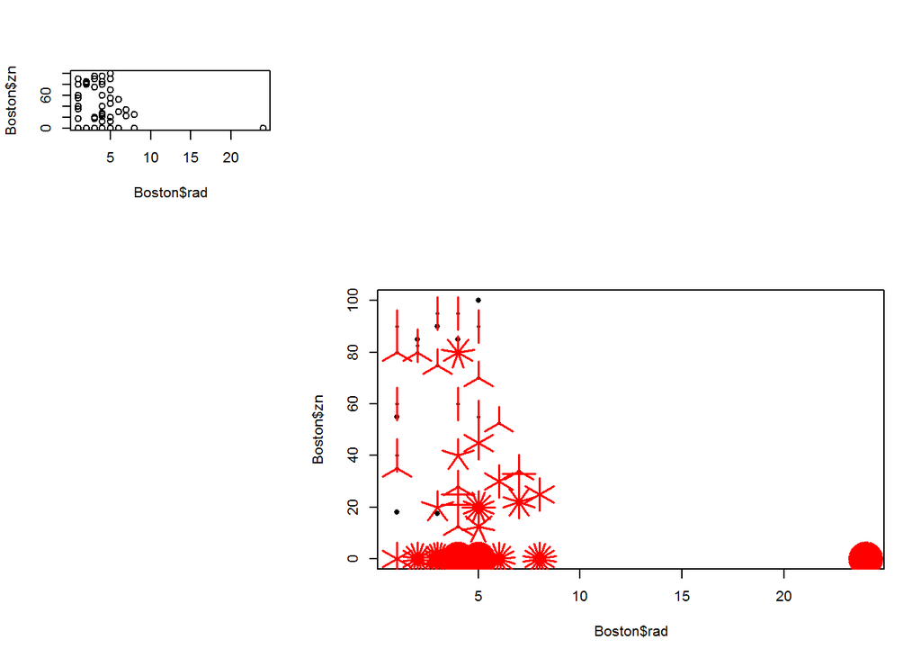

```r
# Create row1, row2, and layoutVector
row1 <- c(1,0,0)
row2 <- c(0,2,2)
layoutVector <- c(row1, row2, row2)

# Convert layoutVector into layoutMatrix
layoutMatrix <- matrix(layoutVector, byrow = TRUE, nrow = 3)

# Set up the plot array
layout(layoutMatrix)

# Plot scatterplot
plot(Boston$rad, Boston$zn)

# Plot sunflower plot
sunflowerplot(Boston$rad, Boston$zn)
```

# Creating & Saving More Complex Plots

Plots often have Side-effects & return values not displayed in the plot itself, but that can be captured with an assignment statement. For example, `barplot()` has the side effect of creating the plot we want, but it also returns a numerical vector with the center positions of each bar in the plot. This value is returned invisibly so we don’t normally see it but we can capture it with an assignment statement.

These return values can be especially useful when we want to overlay text on the bars of a horizontal barplot. Then, we capture the return values and use them as the y parameter in a subsequent call to the text() function, allowing us to place the text at whatever x position we want but overlaid in the middle of each horizontal bar. This exercise asks you to construct a horizontal barplot that exploits these possibilities.

```r
# Create a table of Cylinders frequencies
tbl <- table(Cars93$Cylinders)

tbl
```

```
##
##      3      4      5      6      8 rotary
##      3     49      2     31      7      1
```

```r
# Generate a horizontal barplot of these frequencies
mids <- barplot(tbl, horiz = TRUE,
                col = "transparent")

#mids is now a vector of the midpoints of the barplot we created above.
mids
```

```
##      [,1]
## [1,]  0.7
## [2,]  1.9
## [3,]  3.1
## [4,]  4.3
## [5,]  5.5
## [6,]  6.7
```

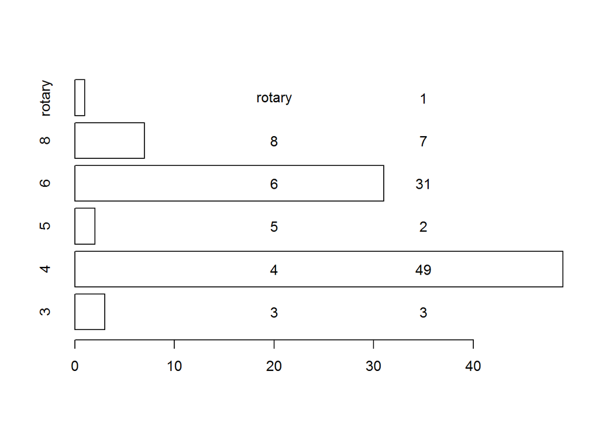

```r
# Add names labels with text()
#text(x = numeric positionon x-axis, y = numeric position on y-axis, labels = vector of labels, )
text(20, y = mids, names(tbl))

# Add count labels with text()
text(35, mids, as.numeric(tbl))
```

The scatterplot allows us to see how one numerical variable changes with the values of a second numerical variable. The `symbols()` function allows us to extend scatterplots to show the influence of other variables.

This function is called with the variables x and y that define a scatterplot, along with another argument that specifies one of several possible shapes. Here, you are asked to use the circles argument to create a bubbleplot where each data point is represented by a circle whose radius depends on the third variable specified by the value of this argument.

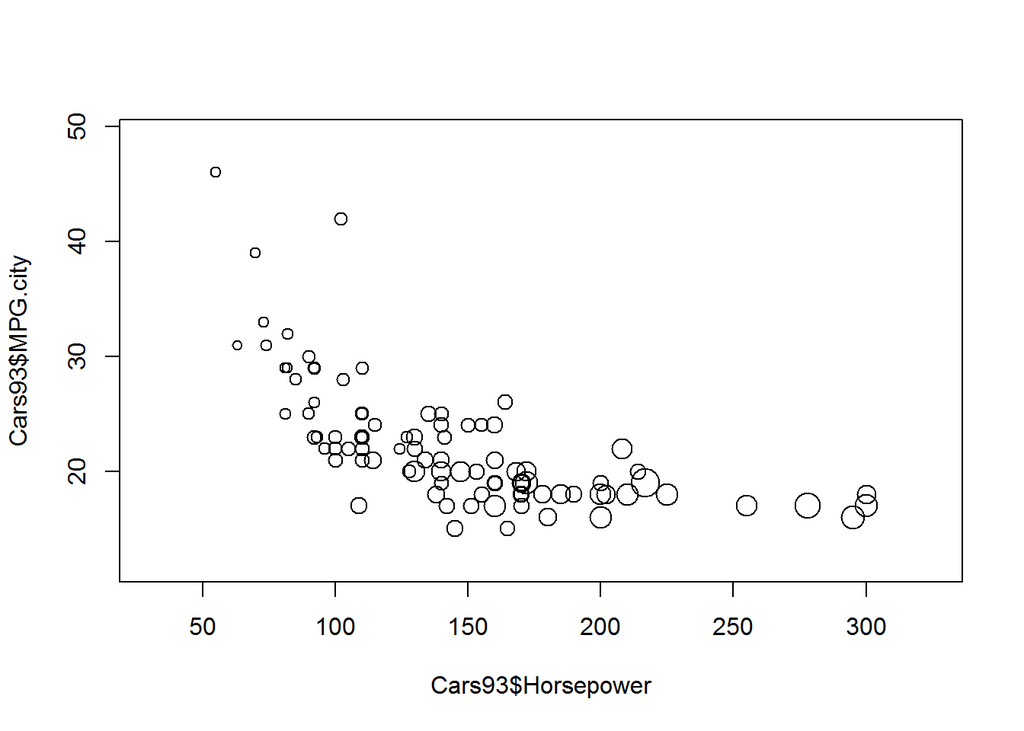

```r
# Call symbols() to create the default bubbleplot
symbols(Cars93$Horsepower, Cars93$MPG.city,
        circles = sqrt(Cars93$Price), inches = 0.1)
```

# Using Color Effectively

Limitations of color: * Color-blindness * Black and white reproductions * Can be overuse and lose usefulness

Illinsky & Steele (Beautiful Visualization) recommend using ideally 6 colors, hopefully no more than 12, and absolutely no more than 20.

This exercise asks you to create a horizontal barplot that shows Iliinsky and Steele’s set of recommended 12 colors, in descending order of desirability from the top of the plot to the bottom. Also, the first six “more preferred” colors are displayed with longer bars to visually emphasize their preferred status over the other six.

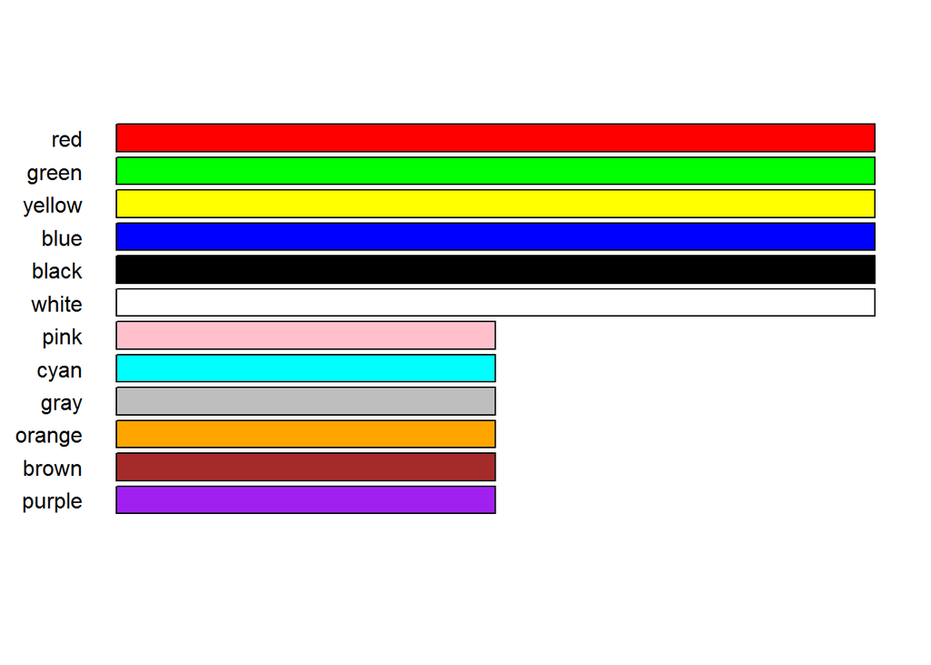

```r
# Iliinsky and Steele color name vector
IScolors <- c("red", "green", "yellow", "blue",
              "black", "white", "pink", "cyan",
              "gray", "orange", "brown", "purple")

# Create the data for the barplot
barWidths <- c(rep(2, 6), rep(1, 6))

# Recreate the horizontal barplot with colored bars
barplot(rev(barWidths), horiz = TRUE,
        col = rev(IScolors), axes = FALSE, names.arg = rev(IScolors), las = 1)
```

Using color to enhance a bubbleplot

```r
# Create the `cylinderLevel` variable
cylinderlevel <- Cars93$Cylinders



#subset the IScolors vector with the levels of cylinder
IScolors[cylinderlevel]
```

```
##  [1] "green"  "blue"   "blue"   "blue"   "green"  "green"  "blue"
##  [8] "blue"   "blue"   "black"  "black"  "green"  "green"  "blue"
## [15] "green"  "blue"   "blue"   "black"  "black"  "blue"   "green"
## [22] "blue"   "green"  "green"  "green"  "blue"   "green"  "blue"
## [29] "green"  "blue"   "green"  "green"  "green"  "green"  "green"
## [36] "blue"   "blue"   "black"  "red"    "green"  "green"  "green"
## [43] "green"  "green"  "green"  "green"  "green"  "black"  "blue"
## [50] "blue"   "blue"   "black"  "green"  "green"  "green"  "blue"
## [57] "white"  "green"  "blue"   "green"  "blue"   "green"  "blue"
## [64] "green"  "green"  "blue"   "blue"   "green"  "green"  "blue"
## [71] "blue"   "green"  "green"  "green"  "blue"   "blue"   "blue"
## [78] "green"  "green"  "red"    "green"  "green"  "red"    "green"
## [85] "green"  "green"  "green"  "green"  "yellow" "green"  "blue"
## [92] "green"  "yellow"
```

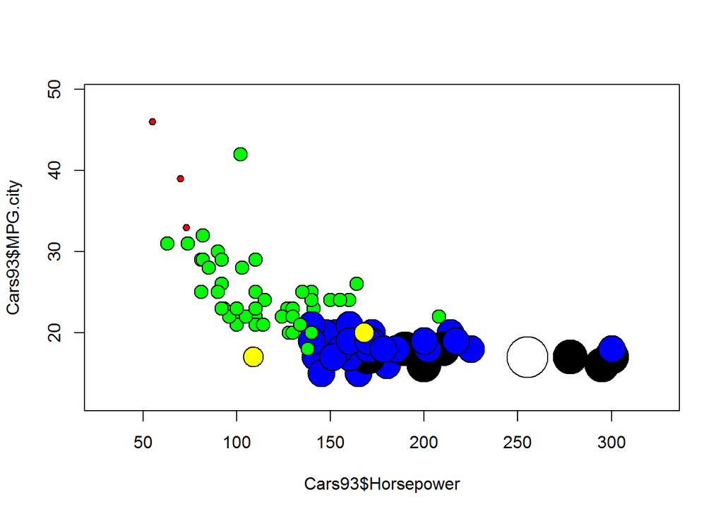

```r
# Create the colored bubbleplot
symbols(Cars93$Horsepower, Cars93$MPG.city, circles = as.numeric(Cars93$Cylinders), inches = 0.2, bg = IScolors[cylinderlevel])
```

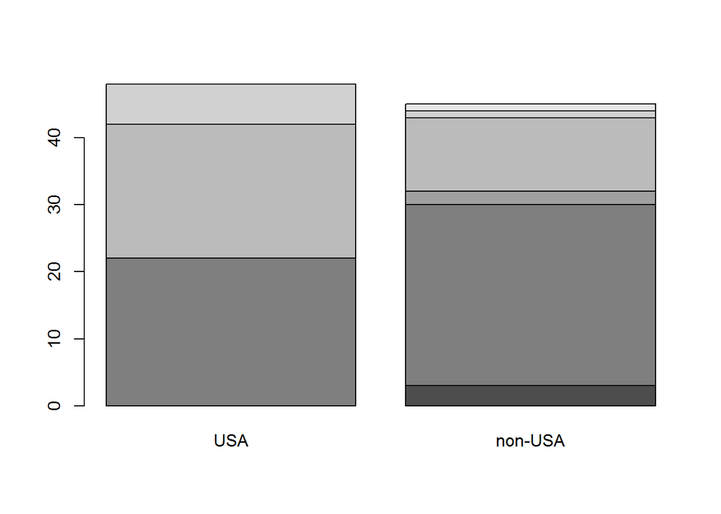

```r
# Create a table of Cylinders by Origin
tbl <- table(Cars93$Cylinders, by = Cars93$Origin)

# Create the default stacked barplot
barplot(tbl)
```

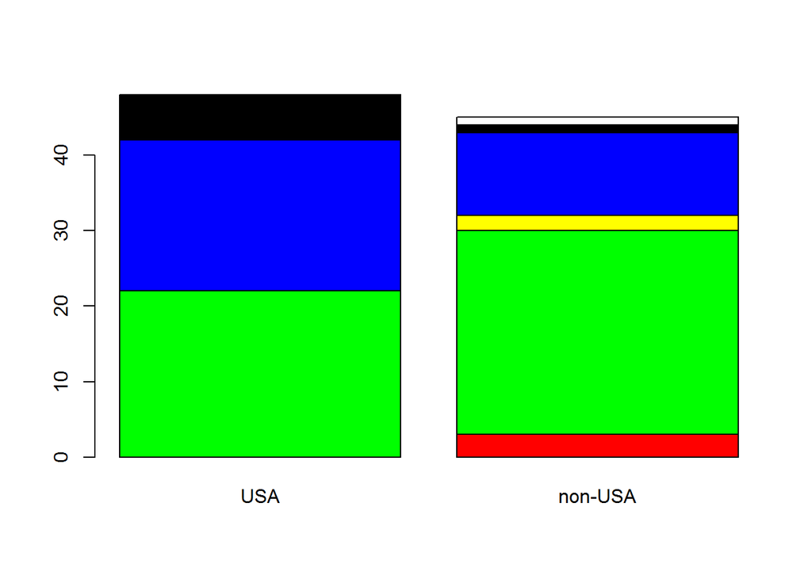

```r
# Enhance this plot with color
barplot(tbl, col = IScolors)
```